# ggplot2 Visualizing Data

## Setup

```r
library(dplyr)
library(ggplot2)
library(readr)
```

## Import data

```r
gapminder <- read_tsv("gapminder.tsv", col_names = TRUE)
```

## Subset the Data

When you’re working on visualizing only a subset of data its useful to save that data as a new data frame. These examples are working with the data from 2007 so we save that as a new data frame.

```r
gapminder_07 <- gapminder %>%
    filter(year == 2007)
```

## Three parts to a ggplot graph

1. the data we’re visualizing (gapminder_07)
2. mapping variables in your data to aesthetics in your graph
3. sepcify the type of graph you’re creating by adding a geom layer (for example). Geom means you’re adding a type of geometeric object to the graph. The point indicates a scatterplot.

Suppose you want to examine the relationship between a country’s wealth and its life expectancy. You could put GDP per capita on the x-axis and life expectancy on the y-axis

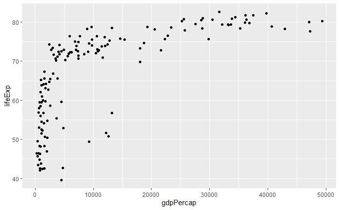

```r
# relationship bewteen a country's wealth and life expectancy for year 2007
ggplot(gapminder_07, aes(x = gdpPercap, y = lifeExp)) +
    geom_point()
```

The probelm with the above plot and some others below is the enormous distribution in scale of the x-axis, with some countries having GDP per capita in the tens of thousands while others are only in the hundreds. When you have a wide distribution like that many observations get crammed into the same area of the plot and can be hard to differentiate. In these graphs, we see it on the left side.

## Log Scales

When you have data with a wide distribution range it’s helpful to use a log scale on the axises. A log scale is a scale where each fixed distance represents a multiplication of the value. So a log-base-10 scale means that the second tick mark on the axis represents a 10x increase over the previous one. Think 10…100…1000…1000.

The plot below is the same data, but now each unit on the x-axis represents a change of 10 times the GDP. And we can see the relationship now looks more linear.

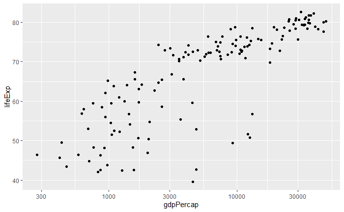

```r
ggplot(gapminder_07, aes(x = gdpPercap, y = lifeExp)) +
  geom_point() +
  scale_x_log10()
```

## Add Color

Continent is a categorical variable. A good way to represent categorical variables is using color.

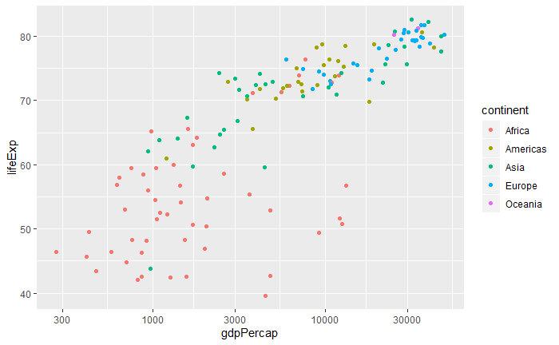

```r
# added color
ggplot(gapminder_07, aes(x = gdpPercap, y = lifeExp,
                         color = continent)) +
  geom_point() +
  scale_x_log10()
```

## Add Size

Population is numerical value so a good way to represent it is in the size of the scattterplot points.

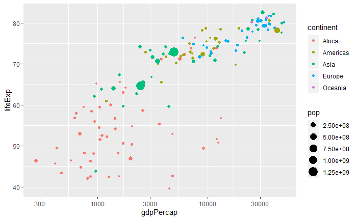

```r
# including population as size of points
ggplot(gapminder_07, aes(x = gdpPercap, y = lifeExp,
                         color = continent,
                         size = pop)) +
  geom_point() +
  scale_x_log10()
```

## Faceting: Divide Your Plot into Smaller Subplots

The tilde `~` means “by”.

**Facet by Continent**

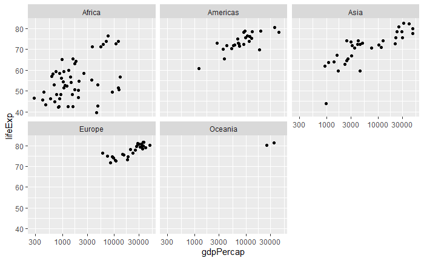

```r
ggplot(gapminder_07, aes(x = gdpPercap, y = lifeExp)) +
  geom_point() +
  scale_x_log10() +
  facet_wrap(~ continent)
```

**Facet by Year**

Notice that we are no longer using a subset of data such as `gapminder_07`. We are using the full data set because we’re working with data from more than one year.

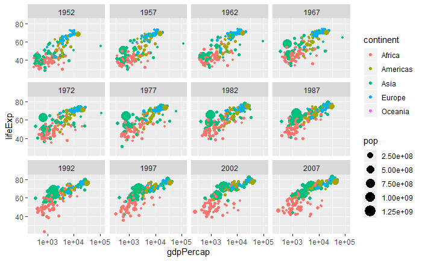

```r
# include color, size, facet by year
ggplot(gapminder, aes(x = gdpPercap, y = lifeExp,
                      color = continent,
                      size = pop)) +
  geom_point() +
  scale_x_log10() +
  facet_wrap(~ year)
```

## `summarize()`

`summarize()` many rows (observations) into a single data point.

You can summarize with the following functions:  
`sum()`  
`mean`  
`median()`  
`min()`  
`max()`

```r
# get average life expectancy across all countries and years
gapminder %>%
  summarize(meanLifeExp = mean(lifeExp))
```

| meanLifeExp |
| --- |
| 59.47444 |

```r
NA
```

But it doesn’t really make sense to summarize across all countries and all years. It may make more sense to get the averages in a particular year, then summmarize the result

```r
# average life expectancy in the year 2007
gapminder %>%
  filter(year == 2007) %>%
  summarize(meanLifeExp = mean(lifeExp))
```

| meanLifeExp |
| --- |
| 67.00742 |

You can create multiple summaries at once. Suppose you also want the total population in 2007.

```r
# summarize two variables at once
gapminder %>%
  filter(year == 2007) %>%
  summarize(meanLifeExp = mean(lifeExp),
            totalPop = sum(pop))
```

| meanLifeExp | totalPop |
| --- | --- |
| 67.00742 | 6251013179 |

#### practice

```r
# find median life expectancy
gapminder %>%
  summarize(medianLifeExp = median(lifeExp))
```

| medianLifeExp |
| --- |
| 60.7125 |

```r
# Filter for 1957 then summarize the median life expectancy
gapminder %>%
    filter(year == 1957) %>%
    summarize(medianLifeExp = median(lifeExp))
```

| medianLifeExp |
| --- |
| 48.3605 |

```r
# Filter for 1957 then summarize the median life expectancy and the maximum GDP per capita
gapminder %>%
  filter(year == 1957) %>%
  summarize(medianLifeExp = median(lifeExp),
            maxGdpPercap = max(gdpPercap))
```

| medianLifeExp | maxGdpPercap |
| --- | --- |
| 48.3605 | 113523.1 |

## `group_by()`

The `group_by()` function lets you summarize within groups instead of summarizing th eentire data set.

What if we’re just interested for the average for each year of the data set? This replaces `filter(year == 2007)`.

```r
# subset data by year for all the countries
# then summarize mean life expectancy & population
gapminder %>%
    group_by(year) %>%
    summarize(meanLifeExp = mean(lifeExp),
              totalPop = sum(pop))
```

| year | meanLifeExp | totalPop |
| --- | --- | --- |
| 1952 | 49.05762 | 2406957150 |
| 1957 | 51.50740 | 2664404580 |
| 1962 | 53.60925 | 2899782974 |
| 1967 | 55.67829 | 3217478384 |
| 1972 | 57.64739 | 3576977158 |
| 1977 | 59.57016 | 3930045807 |
| 1982 | 61.53320 | 4289436840 |
| 1987 | 63.21261 | 4691477418 |
| 1992 | 64.16034 | 5110710260 |
| 1997 | 65.01468 | 5515204472 |

[output cut: 2 more lines]

Summarize by continent.

```r
# year 2007 data, group by continent
gapminder %>%
    filter(year == 2007) %>%
    group_by(continent) %>%
    summarize(meanLifeExp = mean(lifeExp),
              totalPop = sum(pop))
```

| continent | meanLifeExp | totalPop |
| --- | --- | --- |
| Africa | 54.80604 | 929539692 |
| Americas | 73.60812 | 898871184 |
| Asia | 70.72848 | 3811953827 |
| Europe | 77.64860 | 586098529 |
| Oceania | 80.71950 | 24549947 |

```r
NA
```

Now, we’re interested in how these changed over time. This will help you get to per year per capita information.

```r
# summarize by continent and year
gapminder %>%
    group_by(year, continent) %>%
    summarize(meanLifeExp = mean(lifeExp),
              totalPop = sum(pop))
```

| year | continent | meanLifeExp | totalPop |
| --- | --- | --- | --- |
| 1952 | Africa | 39.13550 | 237640501 |
| 1952 | Americas | 53.27984 | 345152446 |
| 1952 | Asia | 46.31439 | 1395357351 |
| 1952 | Europe | 64.40850 | 418120846 |
| 1952 | Oceania | 69.25500 | 10686006 |
| 1957 | Africa | 41.26635 | 264837738 |
| 1957 | Americas | 55.96028 | 386953916 |
| 1957 | Asia | 49.31854 | 1562780599 |
| 1957 | Europe | 66.70307 | 437890351 |
| 1957 | Oceania | 70.29500 | 11941976 |

[output cut: 50 more lines]

#### practice

Summarize by year.

```r
# Find median life expectancy and maximum GDP per capita in each year
gapminder %>% group_by(year) %>%
    summarize(medianLifeExp = median(lifeExp),
              maxGdpPercap = max(gdpPercap))
```

| year | medianLifeExp | maxGdpPercap |
| --- | --- | --- |
| 1952 | 45.1355 | 108382.35 |
| 1957 | 48.3605 | 113523.13 |
| 1962 | 50.8810 | 95458.11 |
| 1967 | 53.8250 | 80894.88 |
| 1972 | 56.5300 | 109347.87 |
| 1977 | 59.6720 | 59265.48 |
| 1982 | 62.4415 | 33693.18 |
| 1987 | 65.8340 | 31540.97 |
| 1992 | 67.7030 | 34932.92 |
| 1997 | 69.3940 | 41283.16 |

[output cut: 2 more lines]

Summarize by continent

```r
# Find median life expectancy and maximum GDP per capita in each continent in 1957
gapminder %>%
    filter(year == 1957) %>%
    group_by(continent) %>%
    summarize(medianLifeExp = median(lifeExp),
              maxGdpPercap = max(gdpPercap))
```

| continent | medianLifeExp | maxGdpPercap |
| --- | --- | --- |
| Africa | 40.5925 | 5487.104 |
| Americas | 56.0740 | 14847.127 |
| Asia | 48.2840 | 113523.133 |
| Europe | 67.6500 | 17909.490 |
| Oceania | 70.2950 | 12247.395 |

Summarize by continent and year.

```r
# Find median life expectancy and maximum GDP per capita in each year/continent combination
gapminder %>%
    group_by(continent, year) %>%
    summarize(medianLifeExp = median(lifeExp),
              maxGdpPercap = max(gdpPercap))
```

| continent | year | medianLifeExp | maxGdpPercap |
| --- | --- | --- | --- |
| Africa | 1952 | 38.8330 | 4725.296 |
| Africa | 1957 | 40.5925 | 5487.104 |
| Africa | 1962 | 42.6305 | 6757.031 |
| Africa | 1967 | 44.6985 | 18772.752 |
| Africa | 1972 | 47.0315 | 21011.497 |
| Africa | 1977 | 49.2725 | 21951.212 |
| Africa | 1982 | 50.7560 | 17364.275 |
| Africa | 1987 | 51.6395 | 11864.408 |
| Africa | 1992 | 52.4290 | 13522.158 |
| Africa | 1997 | 52.7590 | 14722.842 |

[output cut: 50 more lines]

## Visualizing Summarized Data

Subset your data by year.

[output not shown]

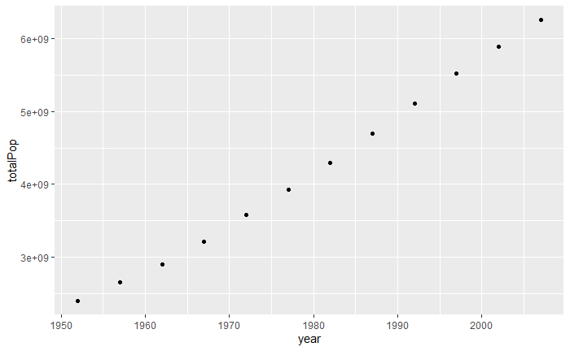

The population growth distribution is so large that tye y-axis is in scientific notation. The graph is also a little misleading because it doesn’t include zero so you don’t have a sence of how much the population grew relative to where it was when it started.

## 1952 Examples

Filter gapminder for observations from the year 1952, and assign it to a new dataset gapminder_1952.

```r
# subset the data
gapminder_1952 <- gapminder %>%
    filter(year == 1952)
```

### Example 1: Y-axis is GDP per capita

#### Population (x-axis) & GDP per capita (y-axis)

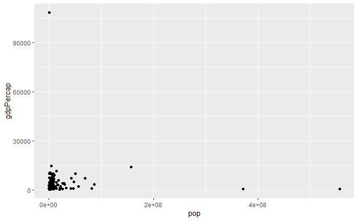

```r
# population on x-axis, GDP per capita on y-axis
ggplot(gapminder_1952, aes(x = pop, y = gdpPercap)) +
  geom_point()
```

#### Log10 scale for both x-axis & y-axis

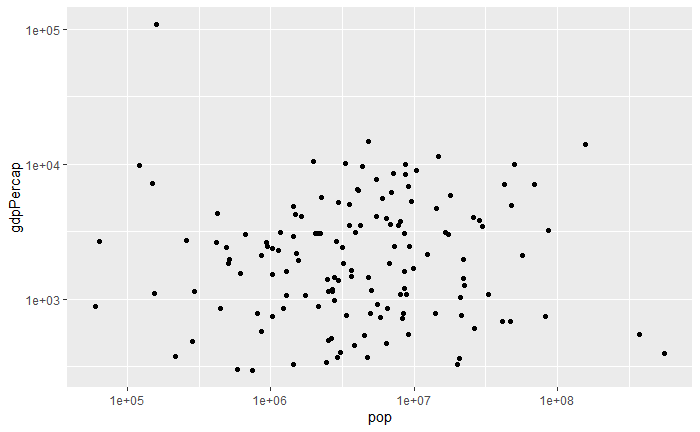

```r
ggplot(gapminder_1952, aes(x = pop, y = gdpPercap)) +
  geom_point() +
  scale_x_log10() +
  scale_y_log10()
```

### Example 2: Y-axis is Life Expectancy

#### Population (x-axis) & Life Expectancy (y-axis)

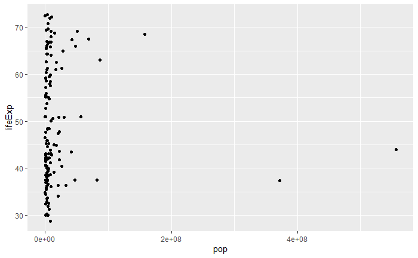

```r
# pop on the x-axis and lifeExp on the y-axis
ggplot(gapminder_1952, aes(x = pop, y = lifeExp)) +
    geom_point()
```

#### x-axis on Log10 scale

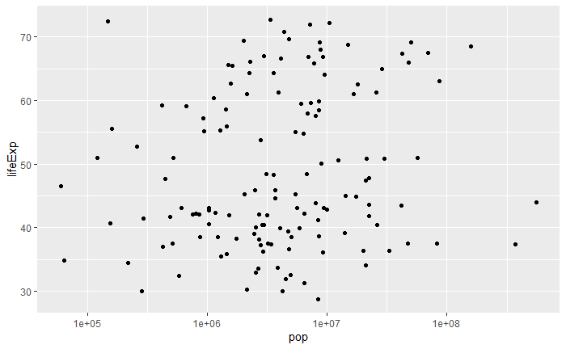

```r
ggplot(gapminder_1952, aes(x = pop, y = lifeExp)) +
  geom_point() +
  scale_x_log10()
```

#### Add Color

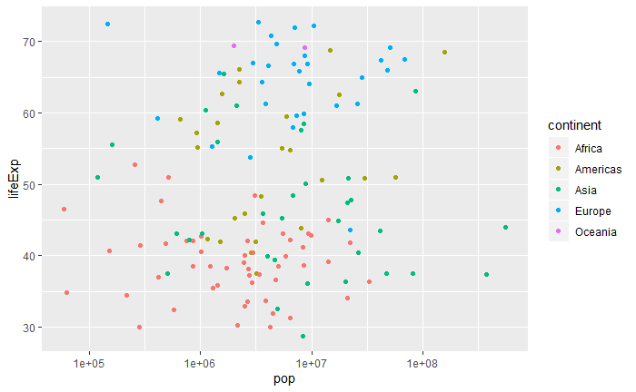

```r
# including color
ggplot(gapminder_1952, aes(x = pop, y = lifeExp,
                           color = continent)) +
  geom_point() +
  scale_x_log10()
```

#### Add size

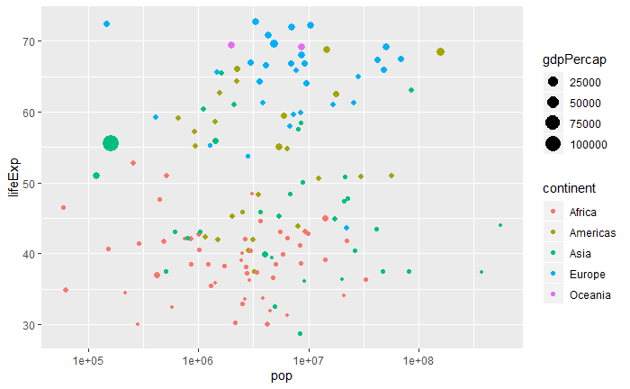

```r
# including size
ggplot(gapminder_1952, aes(x = pop, y = lifeExp,
                           color = continent,
                           size = gdpPercap)) +
  geom_point() +
  scale_x_log10()
```

#### Facet by Continent

We remove the color aesthetic because all the points in each graph would be the same color and it would add an unncessary legend.

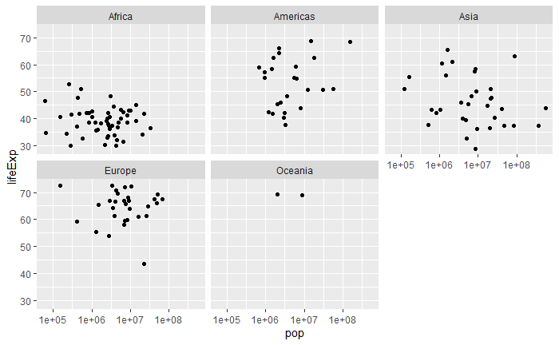

```r
# Facet by continent, need to remove color
ggplot(gapminder_1952, aes(x = pop, y = lifeExp)) +
  geom_point() +
  scale_x_log10() +
  facet_wrap(~ continent)
```